# hw5

**Автор - Федоров А. Н.**  
*Выводы промежуточных клеток удалены для краткости.*

```python
import subprocess

import numpy as np
import matplotlib.pyplot as plt

from scipy import optimize
```

```python
TEMPLATE = '''!HF RHF 6-31G
* int 0 1
C 0 0 0 0 0 0
C 1 0 0 {length} 0 0
H 1 2 0 1.08439 {hcc} 0
H 1 2 3 1.08439 {hcc} 120
H 1 2 3 1.08439 {hcc} -120
H 2 1 3 1.08439 {hcc} {tors1}
H 2 1 5 1.08439 {hcc} {tors2}
H 2 1 5 1.08439 {hcc} {tors3}
*
'''
```

```python
def orca_workload(length=1.52986, hcc=111.200, tors=180):
    return TEMPLATE.format(length=length, hcc=hcc, tors1=tors, tors2=tors-60, tors3=tors+60)

def run_orca(workload):
    with open("/tmp/orca.inp", 'w') as file:
        file.write(workload)

    p = subprocess.Popen("/home/shad/progs/bin/orca /tmp/orca.inp",
                         shell=True, stdout=subprocess.PIPE, stderr=subprocess.PIPE)
    out = p.communicate()[0].decode()
    out = [x for x in out.splitlines() if "FINAL SINGLE POINT ENERGY" in x]
    assert len(out) == 1
    energy = out[0].lstrip("FINAL SINGLE POINT ENERGY").strip()
    return float(energy)
```

```python
def fit(x, y, tofit, init_params):
    loss = lambda params, _x, _y: tofit(params, _x) - _y

    params, _ = optimize.leastsq(loss, init_params[:], args=(x, y))
    return params, lambda x: tofit(params, x)


def plot_fitted(x, y, func):
    plt.scatter(x, y, color='blue', alpha=0.5)

    linx = np.linspace(min(x), max(x), 100)
    predy = func(linx)
    plt.plot(linx, predy, color='green')

    plt.grid()

    plt.margins(y = 0.005 * (max(y) - min(y)))

    print("MSE: {0}".format(np.square(y - func(x)).mean()))
```

### Зависимость энергии молекулы от длины связи C-C

```python
lengths = np.arange(-0.2, 0.2, step=0.02) + 1.52986
energies = np.asarray([run_orca(orca_workload(length)) for length in lengths])
```

```python
func = lambda p, x: p[0] * pow(p[1] - x, 2) + p[2]
params, func = fit(lengths, energies, func, np.asarray([1, 1, -79]))
```

```
MSE: 1.7128803644657378e-06
Params:  [  0.66824773   1.55389266 -79.08233323]
```

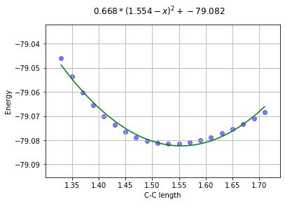

```python
plot_fitted(lengths, energies, func)

plt.suptitle("${0:.3f}*({1:.3f} - x)^2 + {2:.3f}$".format(*params))
plt.xlabel("C-C length")
plt.ylabel("Energy")

print("Params: ", params)
```

### Зависимость энергии молекулы от валентного угла HCC

```python
hcc = np.linspace(109.2, 113.2, 20)
energies = np.asarray([run_orca(orca_workload(hcc=e)) for e in hcc])
```

```python
func = lambda p, x: p[0] * pow(p[1] - x, 2) + p[2]
params, func = fit(hcc, energies, func, np.asarray([1, 1, -79]))
```

```
MSE: 1.1104829246246953e-12
Params:  [ 3.31057253e-04  1.12270856e+02 -7.90819111e+01]
```

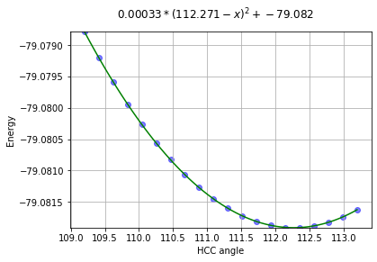

```python
plot_fitted(hcc, energies, func)

plt.suptitle("${0:.5f}*({1:.3f} - x)^2 + {2:.3f}$".format(*params))
plt.xlabel("HCC angle")
plt.ylabel("Energy")

plt.ylim(min(energies), max(energies))
print("Params: ", params)
```

### Сравнение констант

*Сравните полученные константы с данными из статьи о GAFF. Укажите возможные причины расхождений ваших результатов и публикацией.*

Не очень понятно о каких именно константах идет речь. Вероятно, о bond stretching force constant и bond angle force constant - это константы $K_r$ и $K_{\theta}$ в уравнении 1. В нашем случае - это просто множители в формуле параболы.

**Связь С-С**

В статье авторов имеем (figure 2): $$ln(K_r) = -4.9575r +7.8187$$ Тогда при равновесной длине связи $r = 1.52986$: $$K_r = exp(-4.9575*1.52986 + 7.8187)=302.14 \frac{ккал}{моль \cdot Å^2}$$ Из нашего уравнения имеем $\hat{K_r} = 0.668 E_h$, где $E_h = 627.51\frac{ккал}{моль}$. Тогда: $$\hat{K_r} = 0.668 * 627.51 = 419.18\frac{ккал}{моль \cdot Å^2}$$

Порядок величин такой же. Однако, не очень ясно, насколько влияет полученное различие в прикладных задачах.

**Валентный угол HCC**

Воспользуемся формулой 5 из исходной статьи, эмпирические параметры возьмем из таблицы 4.

```python
Zi = 0.784
Cj = 1.339
Zk = 1.183
r_ij = 1.08439
r_jk = 1.52986
theta_ijk = np.deg2rad(111.2)

143.9 * Zi * Cj * Zk * (r_ij + r_jk) ** -1 * (theta_ijk) ** -2 * np.exp(-2 * ((r_ij - r_jk) / (r_ij + r_jk))**2)
```

```
17.124190870828155
```

Получаем $K_{\theta}=17.124 \frac{ккаль}{моль \cdot рад^2}$

В наших вычислениях имеем: $$\hat{K_{\theta}} = 0.00033 * 627.51 \frac{ккал}{моль \cdot град^2} = 682.668 \frac{ккал}{моль \cdot рад^2}$$

Что на порядок отличается от константы из статьи.

Наблюдаемые различия частично могут быть связаны с разностью подходов - точная квантовая химия(orca) и эмпирические модели молекулярной динамики(gaff). Они хорошо согласуются в энергии растяжения связи, однако молекулярная динамика сильно загрубляет при оценки энергии поворота связи.

P.S. Честно сказать, я не уверен, что не ошибся в расчетах и измерениях. Особенно в расчетах для валентного угла HCC.

### Зависимость энергии молекулы от торсионного угла CС

```python
tors = np.arange(-180, 181, 12)
energies = np.asarray([run_orca(orca_workload(tors=t)) for t in tors])
```

```python
func = lambda p, x: p[0] * np.cos(p[1] * np.deg2rad(x) + p[2]) + p[3]
params, func = fit(tors, energies, func, np.asarray([1, 1, 1, -79]))
```

```
MSE: 5.705918533930543e-12
```

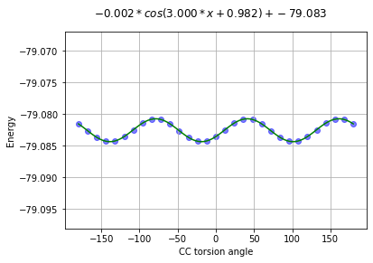

```python
plot_fitted(tors, energies, func)

plt.suptitle("${0:.3f} * cos({1:.3f} * x + {2:.3f}) + {3:.3f}$".format(*params))
plt.xlabel("CC torsion angle")
plt.ylabel("Energy")
```

Как видно из графика, на окружности $[-\pi, \pi]$ у функции 3 минимума => у нее всего 3 минимума.

### Зависимость энергии молекулы от длины связи C-C (шаг 0.1 Å)

```python
lengths = np.arange(-10, 10) * 0.1 + 1.52986
energies = np.asarray([run_orca(orca_workload(length)) for length in lengths])
```

```python
func = lambda p, x: p[0] * np.exp(p[1] * x + p[2]) + p[3]
params, func = fit(lengths, energies, func, np.asarray([1, -1, 1, -79]))
```

```
MSE: 0.0037107289538635575
```

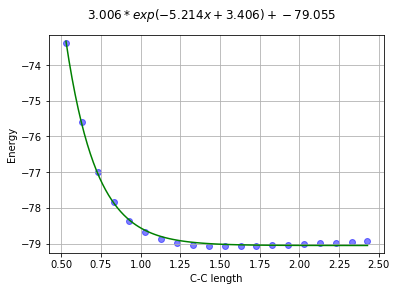

```python
plot_fitted(lengths, energies, func)

plt.suptitle("${0:.3f}*exp({1:.3f}x + {2:.3f}) + {3:.3f}$".format(*params))
plt.xlabel("C-C length")
plt.ylabel("Energy")
```

Наблюдаемая зависимость отлично аппроксимируется экспонентой.

```python
!jupyter nbconvert hw5.ipynb --to html
```

```
[NbConvertApp] Converting notebook hw5.ipynb to html
[NbConvertApp] Writing 367211 bytes to hw5.html
```